# Chapter 12 — Bayesian Statistics (R companion)

R/tidyverse translation of *Understanding Data by Alan Garfinkel and Yina Guo

Adrian Soto-Mota, MD, PhD, FACP.

2026-04-24

# Orientation

Chapter 12 (book pp. 595–665) is the paradigm shift. The p-value answers *P(data | H₀)* — the probability of the data if the null is true. What clinicians, policy makers, and scientists actually want is *P(H | data)* — the probability the hypothesis is true given the data. **Bayes’ theorem gets you the second from the first.** *(Book §12.1 “Answering the wrong question”, p. 595.)*

# §12.2 — Positive Predictive Value: the disease-test example *(book §12.2 “Positive Predictive Value in medicine and social science”, p. 597)*

## The setup

A diagnostic test is 99 % sensitive and 99 % specific. A patient tests positive. What’s the probability they actually have the disease?

```r
sensitivity <- 0.99        # P(test+ | disease)
specificity <- 0.99        # P(test− | no disease)
prevalence  <- 0.001       # 1 in 1000 has the disease
```

## Graphical approach: the natural frequency tree *(book §12.2 “Graphical approaches”, p. 602)*

```r
N          <- 100000       # think about 100,000 people
disease    <- N * prevalence                    # 100 sick
no_disease <- N - disease                       # 99,900 healthy

true_pos   <- disease    * sensitivity          # 99 sick test+
false_neg  <- disease    * (1 - sensitivity)    # 1 sick test−
false_pos  <- no_disease * (1 - specificity)    # 999 healthy test+
true_neg   <- no_disease * specificity          # 98,901 healthy test−

# PPV = P(disease | test+) = true positives / all positives
PPV <- true_pos / (true_pos + false_pos)
PPV
```

```
## [1] 0.09016393
```

**Only about 9 %** of people who test positive actually have the disease. The specificity is “high” but the false positives (999) overwhelm the true positives (99) because the healthy population is so much larger.

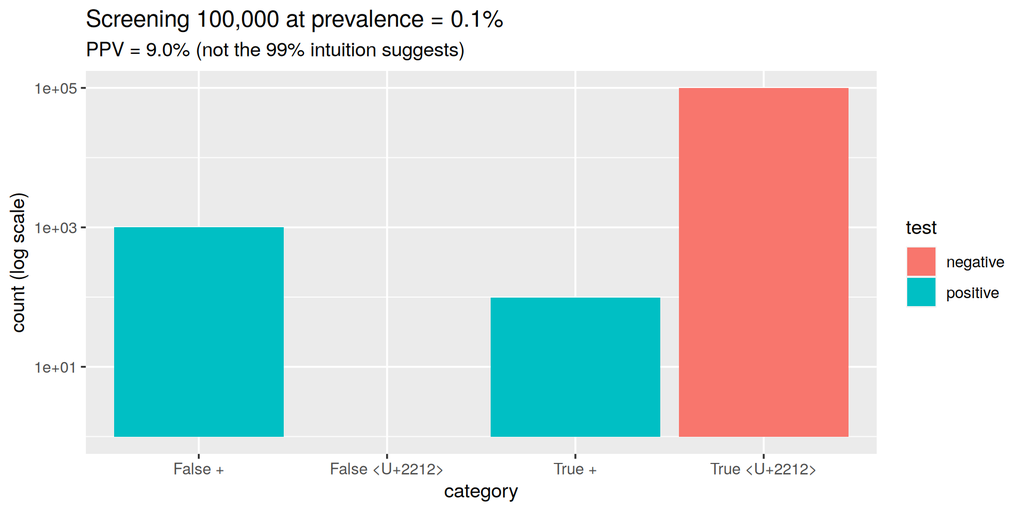

```r
tibble(
  category = c("True +", "False +", "True −", "False −"),
  count    = c(true_pos, false_pos, true_neg, false_neg),
  test     = c("positive", "positive", "negative", "negative")
) |>
  ggplot(aes(category, count, fill = test)) +
  geom_col() +
  scale_y_log10() +
  labs(
    title = sprintf(
      "Screening 100,000 at prevalence = %.1f%%",
      100 * prevalence
    ),
    subtitle = sprintf(
      "PPV = %.1f%% (not the 99%% intuition suggests)",
      100 * PPV
    ),
    y = "count (log scale)"
  )
```

## The prosecutor’s fallacy *(book §12.2, p. 608)*

This is the same error in legal language: **P(evidence | innocent)** is NOT **P(innocent | evidence)**. An expert who testifies “this evidence would occur in only 1 in a million innocent people” is answering the wrong question — and if 10 million innocents were screened, 10 false matches are expected.

# §12.3 — Bayes’ theorem *(book p. 613)*

$$P(H \mid D) = \frac{P(D \mid H) \cdot
P(H)}{P(D)}$$

```r
bayes_update <- function(prior, likelihood_H, likelihood_notH) {
  # P(H | D) = P(D|H) P(H) / [P(D|H) P(H) + P(D|¬H) P(¬H)]
  numerator   <- likelihood_H   * prior
  denominator <- numerator + likelihood_notH * (1 - prior)
  numerator / denominator
}

# Disease example
bayes_update(prior = 0.001, likelihood_H = 0.99, likelihood_notH = 0.01)
```

```
## [1] 0.09016393
```

```r
# Same answer as the natural-frequency tree above
```

## Bayesian updating: incorporating new evidence *(book §12.3 “Bayes as updating”, p. 617)*

Each new test result *updates* the prior. Yesterday’s posterior becomes today’s prior.

```r
# Start with base-rate prior 0.001; patient then takes two independent tests.
p_current <- 0.001

for (test_result in c("positive", "positive")) {
  L_H    <- ifelse(test_result == "positive", 0.99, 0.01)
  L_notH <- ifelse(test_result == "positive", 0.01, 0.99)
  p_current <- bayes_update(p_current, L_H, L_notH)
  cat("After a", test_result, "result, P(disease) =", signif(p_current, 3), "\n")
}
```

```
## After a positive result, P(disease) = 0.0902
## After a positive result, P(disease) = 0.908
```

# §12.4 — Bayes in clinical trials *(book §12.4 “Bayes and Clinical trials”, p. 643)*

The chapter contrasts p-value hypothesis testing with a Bayesian analysis for a clinical trial where we want P(drug works | data).

```r
# Simple Beta-Binomial model
# Observed: 18 of 30 patients improved under the new drug
improved <- 18
n        <- 30

# Prior: Beta(1, 1) is uniform — "no prior opinion on efficacy"
prior_alpha <- 1
prior_beta  <- 1

# Posterior (conjugate update): Beta(α + x, β + n − x)
post_alpha <- prior_alpha + improved
post_beta  <- prior_beta  + (n - improved)

# P(response_rate > 0.5 | data) — probability the drug is more effective than a coin flip
prob_better_than_half <- 1 - pbeta(0.5, post_alpha, post_beta)
prob_better_than_half
```

```
## [1] 0.8594792
```

```r
# 95% credible interval (NOT a confidence interval — see interpretation below)
ci_credible <- qbeta(c(0.025, 0.975), post_alpha, post_beta)
ci_credible
```

```
## [1] 0.4218696 0.7545240
```

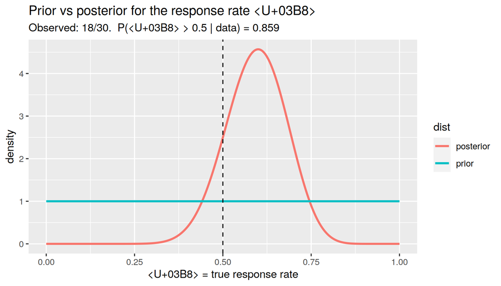

```r
theta <- seq(0, 1, 0.001)

tibble(
  theta     = theta,
  prior     = dbeta(theta, prior_alpha, prior_beta),
  posterior = dbeta(theta, post_alpha, post_beta)
) |>
  pivot_longer(c(prior, posterior), names_to = "dist", values_to = "density") |>
  ggplot(aes(theta, density, color = dist)) +
  geom_line(linewidth = 1) +
  geom_vline(xintercept = 0.5, linetype = "dashed") +
  labs(
    title = "Prior vs posterior for the response rate θ",
    subtitle = sprintf(
      "Observed: %d/%d.  P(θ > 0.5 | data) = %.3f",
      improved, n, prob_better_than_half
    ),
    x = "θ = true response rate",
    y = "density"
  )
```

## Credible interval vs confidence interval — the crucial difference

- **Confidence interval** (Ch. 4): *a 95 % CI is a procedure such that, over many repetitions, 95 % of intervals will contain the true parameter.* It is NOT a probability statement about this particular interval.
- **Credible interval**: *given these data, there is a 95 % probability the true parameter lies in this interval.*

The second is what everyone wants the first to mean. The Bayesian definition delivers it directly — at the cost of requiring a prior.

# §12.5 — Why most published findings may be wrong *(book §12.5 “Bayes’ Theorem and the problem of unreliable results”, p. 656)*

A famous Ioannidis-style exercise: even with α = 0.05 and 80 % power, **most published positive findings may be false** if the prior probability that the tested hypothesis is true is low.

```r
# Suppose we test many hypotheses, only 10% of which are true
prior_true <- 0.10
alpha      <- 0.05      # Type I rate
power      <- 0.80      # 1 − β

# P(hypothesis true | positive result) by Bayes
prob_true_given_positive <- bayes_update(
  prior           = prior_true,
  likelihood_H    = power,    # true positives
  likelihood_notH = alpha     # false positives
)

prob_true_given_positive
```

```
## [1] 0.64
```

**Only ~64 %** of published “significant” findings are true under these generous assumptions. Lower the prior (exploratory fishing), lower the power (small studies), and this drops further:

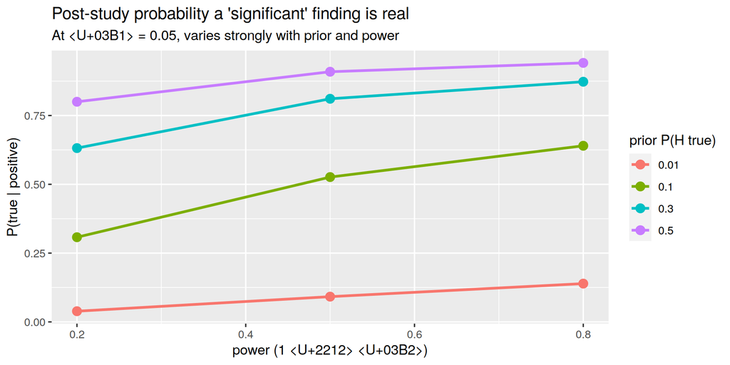

```r
grid <- expand_grid(
  prior = c(0.01, 0.10, 0.30, 0.50),
  power = c(0.20, 0.50, 0.80)
) |>
  mutate(
    ppv = pmap_dbl(
      list(prior, power),
      \(p, pw) bayes_update(p, pw, 0.05)
    )
  )

ggplot(grid, aes(power, ppv, color = factor(prior))) +
  geom_line(linewidth = 1) +
  geom_point(size = 3) +
  labs(
    title = "Post-study probability a 'significant' finding is real",
    subtitle = "At α = 0.05, varies strongly with prior and power",
    x = "power (1 − β)",
    y = "P(true | positive)",
    color = "prior P(H true)"
  )
```

# The paradigm shift *(companion synthesis of Ch. 12)*

- **Frequentism**: probability = long-run frequency. Parameters are fixed. Procedures calibrated so that error rates (α, β) are controlled across hypothetical replications.
- **Bayesianism**: probability = degree of belief. Parameters have distributions. Evidence updates belief via Bayes’ theorem.

The two agree on many numerical results but differ on the *meaning* of those numbers — and only Bayes answers the question people most want answered.

# Exercises

1. Repeat the disease-test calculation with prevalence 1/100 instead of 1/1000. How does PPV change? What does this say about screening programs in high- vs low-prevalence populations?
2. With prior Beta(1, 1), observed 18/30 improvements: compute the posterior probability the drug beats a placebo with a 40 % response rate. Repeat with an informative prior Beta(20, 20), which represents a strong belief in 50 %. How much does the prior matter?
3. Implement Ioannidis’s PPV formula algebraically:

   `PPV = (1−β)R / ((1−β)R + α)`

   where `R = prior / (1 − prior)`. Verify it against `bayes_update()`.